# PA_HW5

Group10

2022-11-08

# Problem 3

### 3(a)

```r
library(MASS)
# dim(Boston)
Boston$logcrim = log(Boston$crim) # create log transform of crim
# summary(Boston)
set.seed(12345)
train = runif(nrow(Boston))<.5 # pick train/test split
print("Frequency Distribution")
```

```
## [1] "Frequency Distribution"
```

```r
table(train) # frequency distribution
```

```
## train
## FALSE  TRUE
##   282   224
```

### 3(b)

```r
fit1 = lm(logcrim ~ . - crim, data = Boston, subset=train)
# summary(fit1)
p1 = predict(fit1, Boston[!train,])
# MSE
mse_test = mean((Boston$logcrim[!train] - p1)^2)
mse_test
```

```
## [1] 0.7083435
```

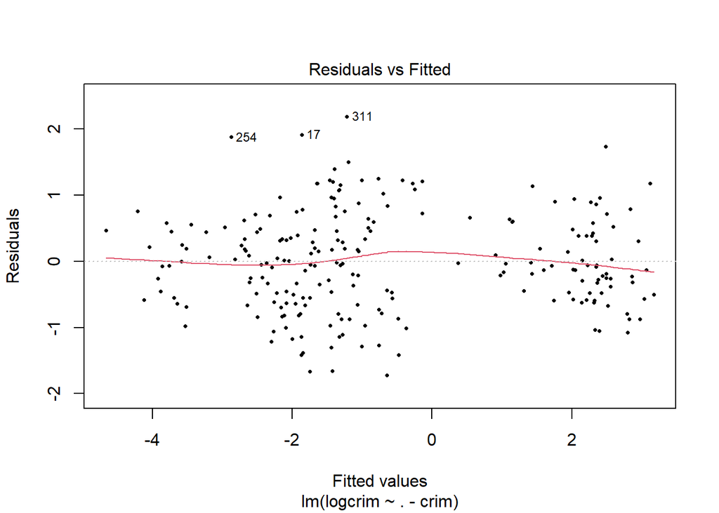

```r
# residual plot
plot(fit1, which = 1, pch = 16, cex = .5)
```

The test set MSE is 0.7083435. From the residual plot,we learn that the variance are not very constant.

### 3(c)

```r
fit2 = step(fit1, trace = F)
p2 = predict(fit2, Boston[!train,])
mean((Boston$logcrim[!train] - p2)^2)
```

```
## [1] 0.7033381
```

The test set MSE is 0.7033381.

### 3(d)

```r
library('glmnet')
# fit ridge
x = model.matrix(logcrim ~ . - crim -1,Boston)
fit_ridge = glmnet(x[train,], Boston$logcrim[train], alpha = 0)

# CV
set.seed(1234)
ridge_cv = cv.glmnet(x[train,], Boston$logcrim[train], alpha = 0) # find optimal lambda
l1 = ridge_cv$lambda.min
l1
```

```
## [1] 0.1866301
```

```r
# test set mse
p3 = predict(fit_ridge, s=l1, newx=x[!train,])
mean((Boston$logcrim[!train] - p3)^2)
```

```
## [1] 0.7767352
```

The test set MSE is 0.7767352.

### 3(e)

```r
# fit lasso
x = model.matrix(logcrim ~ . - crim -1,Boston)
fit_lasso = glmnet(x[train,], Boston$logcrim[train], alpha = 1)

# CV
set.seed(1234)
lasso_cv = cv.glmnet(x[train,], Boston$logcrim[train], alpha = 1) # find optimal lambda
l2 = lasso_cv$lambda.min
l2
```

```
## [1] 0.009288624
```

```r
# test set mse
p4 = predict(fit_lasso, s=l2, newx=x[!train,])
mean((Boston$logcrim[!train] - p4)^2)
```

```
## [1] 0.7023993
```

The test set MSE is 0.7023993.

### 3(f)

```r
# ridge model
x = model.matrix(logcrim ~zn
        +indus+I(indus^2)
        +chas
        +nox+I(nox^2)
        +rm+log(rm)
        +age+log(age)
        +dis+log(dis)
        +rad+log(rad)
        +tax+log(tax)
        +ptratio+log(ptratio)
        +black+log(black)
        +lstat+log(lstat)
        +medv+log(medv), Boston)
fit_r = glmnet(x[train,], Boston$logcrim[train], alpha=0)

fit_cv = cv.glmnet(x[train,], Boston$logcrim[train], alpha=0)
l_r = fit_cv$lambda.min

yhat = predict(fit_r, s=fit_cv$lambda.min, newx=x[!train,])
mean((Boston$logcrim[!train] - yhat)^2)
```

```
## [1] 0.6510401
```

```r
# lasso model
fit_l = glmnet(x[train,], Boston$logcrim[train], alpha=1)

fit_cv2 = cv.glmnet(x[train,], Boston$logcrim[train], alpha=1)
l_l = fit_cv2$lambda.min

yhat2 = predict(fit_l, s=fit_cv2$lambda.min, newx=x[!train,])
mean((Boston$logcrim[!train] - yhat2)^2)
```

```
## [1] 0.5612213
```

```r
# step-wise
fit4= lm(logcrim ~ 1, Boston, subset=train)
fit_s = step(fit4, scope=~zn
        +indus+I(indus^2)
        +chas
        +nox+I(nox^2)
        +rm+log(rm)
        +age+log(age)
        +dis+log(dis)
        +rad+log(rad)
        +tax+log(tax)
        +ptratio+log(ptratio)
        +black+log(black)
        +lstat+log(lstat)
        +medv+log(medv), trace = FALSE)
yhat3 = predict(fit_s, Boston[!train,])
mean((Boston$logcrim[!train] - yhat3)^2)
```

```
## [1] 0.5694736
```

Log transformations and square transformations of predictors are important. Because these transformations help reduce MSE in all three models.

# Problem 4

### 4(a)

```r
sigma = matrix(0.9, nrow=4, ncol=4) + .1*diag(4)
A = chol(sigma)
t(A) %*% A
```

```
##      [,1] [,2] [,3] [,4]
## [1,]  1.0  0.9  0.9  0.9
## [2,]  0.9  1.0  0.9  0.9
## [3,]  0.9  0.9  1.0  0.9
## [4,]  0.9  0.9  0.9  1.0
```

### 4(b)

```r
Z = matrix(rnorm(4000), nrow=1000)
X = Z %*% A
var(X)
```

```
##           [,1]      [,2]      [,3]      [,4]
## [1,] 0.9319924 0.8492134 0.8528907 0.8503184
## [2,] 0.8492134 0.9769819 0.8667180 0.8691371
## [3,] 0.8528907 0.8667180 0.9625422 0.8652925
## [4,] 0.8503184 0.8691371 0.8652925 0.9634800
```

### 4(c)

```r
set.seed(12345)
# generate a new Z, A and X
n = 10100
ntrain=100
ntest=n-ntrain
Z <- matrix(rnorm(n*15), nrow=n)

sigma <- matrix(0.9, nrow=15, ncol=15) + diag(rep(1-0.9, 15))
A <- chol(sigma)
X <- Z %*% A

beta = c(1,-1,1.5,0.5,-0.5,rep(0,10))
e = rnorm(10100)*3
y = 3 + X %*% beta + e

train <- data.frame(X[1:ntrain,], y=y[1:ntrain])
test <- data.frame(X[(ntrain+1):n,], y=y[(ntrain+1):n])
```

### 4(d)

```r
dat = data.frame(X)
dat$y <- y

fit = lm(y~X1+X2+X3+X4+X5,data=train)
summary(fit)
```

```
##
## Call:
## lm(formula = y ~ X1 + X2 + X3 + X4 + X5, data = train)
##
## Residuals:
##     Min      1Q  Median      3Q     Max
## -7.8436 -2.0442  0.2997  1.8333  6.9526
##
## Coefficients:
##             Estimate Std. Error t value Pr(>|t|)
## (Intercept)   3.0256     0.3295   9.183    1e-14 ***
## X1            0.9439     0.8875   1.064  0.29026
## X2           -1.6256     1.0049  -1.618  0.10906
## X3            2.7879     0.8924   3.124  0.00237 **
## X4           -0.3034     1.0439  -0.291  0.77200
## X5           -0.3711     0.8164  -0.455  0.65048
## ---
## Signif. codes:  0 '***' 0.001 '**' 0.01 '*' 0.05 '.' 0.1 ' ' 1
##
## Residual standard error: 3.2 on 94 degrees of freedom
## Multiple R-squared:  0.2407, Adjusted R-squared:  0.2003
## F-statistic: 5.961 on 5 and 94 DF,  p-value: 7.843e-05
```

```r
mean((test$y-predict(fit, test))^2)
```

```
## [1] 9.449501
```

```r
confint(fit)
```

```
##                  2.5 %    97.5 %
## (Intercept)  2.3714294 3.6797538
## X1          -0.8182307 2.7059553
## X2          -3.6208313 0.3695436
## X3           1.0160970 4.5597365
## X4          -2.3759925 1.7692921
## X5          -1.9919717 1.2498126
```

The residual standard error is 3.2. Slopes for xi(i=1,2,3,4,5) are 0.9439, -1.6256, 2.7879, -0.3034, -0.3711. R-squared is 0.2407. Slope for x1 roughly equals the true parameter and the other slops aren’t. Slope for x4 has the wrong sign, other slopes have the right signs. In terms of statistical significance, only slope for x3 is significant at 0.01 level. All the 95% confidence interval covers the true value.

### 4(e)

```r
mean((test$y-predict(fit, test))^2)
```

```
## [1] 9.449501
```

The value of MSE is 9.449501.

### 4(f)

```r
fit_4f = lm(y ~ ., data = train)
summary_4f = summary(fit_4f)
coefs = summary_4f$coefficients

betas_4f = coefs[2:16]
se = coefs[18:32]
ci_l = c()
ci_u = c()
for (idx in 1:length(betas_4f)) {
  ci_l = append(ci_l, (betas_4f[idx] - 2 * se[idx]))
  ci_u = append(ci_u, (betas_4f[idx] + 2 * se[idx]))
}

is_in = c()
for (idx in 1:length(betas_4f)) {
  if ((beta[idx] > ci_l[idx]) & (beta[idx] < ci_u[idx])) {
    is_in = append(is_in, 1)
  } else {
    is_in = append(is_in, 0)
  }
}
vars_in = sum(is_in)
print(summary(fit_4f))
```

```
##
## Call:
## lm(formula = y ~ ., data = train)
##
## Residuals:
##     Min      1Q  Median      3Q     Max
## -7.7768 -1.8727  0.0985  1.8531  6.4236
##
## Coefficients:
##             Estimate Std. Error t value Pr(>|t|)
## (Intercept)  3.09711    0.34378   9.009 5.69e-14 ***
## X1           1.64535    1.01410   1.622  0.10845
## X2          -1.27455    1.12632  -1.132  0.26102
## X3           3.04446    0.99629   3.056  0.00301 **
## X4           0.17894    1.16865   0.153  0.87867
## X5           0.12057    0.95410   0.126  0.89974
## X6           0.42167    1.04928   0.402  0.68880
## X7          -0.05058    1.16496  -0.043  0.96547
## X8          -1.48874    1.18517  -1.256  0.21255
## X9           1.02701    1.03928   0.988  0.32589
## X10         -0.83981    1.13596  -0.739  0.46179
## X11          0.68516    1.02798   0.667  0.50691
## X12         -0.55163    1.07908  -0.511  0.61055
## X13         -1.25600    1.22391  -1.026  0.30773
## X14          0.52319    1.01348   0.516  0.60705
## X15         -0.73817    1.23259  -0.599  0.55086
## ---
## Signif. codes:  0 '***' 0.001 '**' 0.01 '*' 0.05 '.' 0.1 ' ' 1
##
## Residual standard error: 3.258 on 84 degrees of freedom
## Multiple R-squared:  0.2964, Adjusted R-squared:  0.1708
## F-statistic: 2.359 on 15 and 84 DF,  p-value: 0.007036
```

### 4(g)

```r
mse_4g = mean((test$y-predict(fit_4f, test))^2)
```

The MSE is 10.2347653 for the full model.

### 4(h)

```r
step_4h = stepAIC(lm(y ~., data = train),
                  direction = "both",
                  trace = F)
summary(step_4h)
```

```
##
## Call:
## lm(formula = y ~ X1 + X3 + X8 + X13, data = train)
##
## Residuals:
##     Min      1Q  Median      3Q     Max
## -7.2310 -1.8975  0.2254  1.6861  7.4489
##
## Coefficients:
##             Estimate Std. Error t value Pr(>|t|)
## (Intercept)   3.0673     0.3217   9.533 1.64e-15 ***
## X1            1.3978     0.8835   1.582 0.116921
## X3            3.0285     0.8466   3.577 0.000548 ***
## X8           -1.5716     0.9797  -1.604 0.112011
## X13          -1.4510     1.0226  -1.419 0.159185
## ---
## Signif. codes:  0 '***' 0.001 '**' 0.01 '*' 0.05 '.' 0.1 ' ' 1
##
## Residual standard error: 3.14 on 95 degrees of freedom
## Multiple R-squared:  0.2609, Adjusted R-squared:  0.2297
## F-statistic: 8.382 on 4 and 95 DF,  p-value: 7.787e-06
```

The “right” variables did not come into the model.

### 4(i)

```r
mse_4i = mean((test$y-predict(step_4h, test))^2)
```

The MSE is 10.0442626 for the model found using stepAIC.

### 4(j)

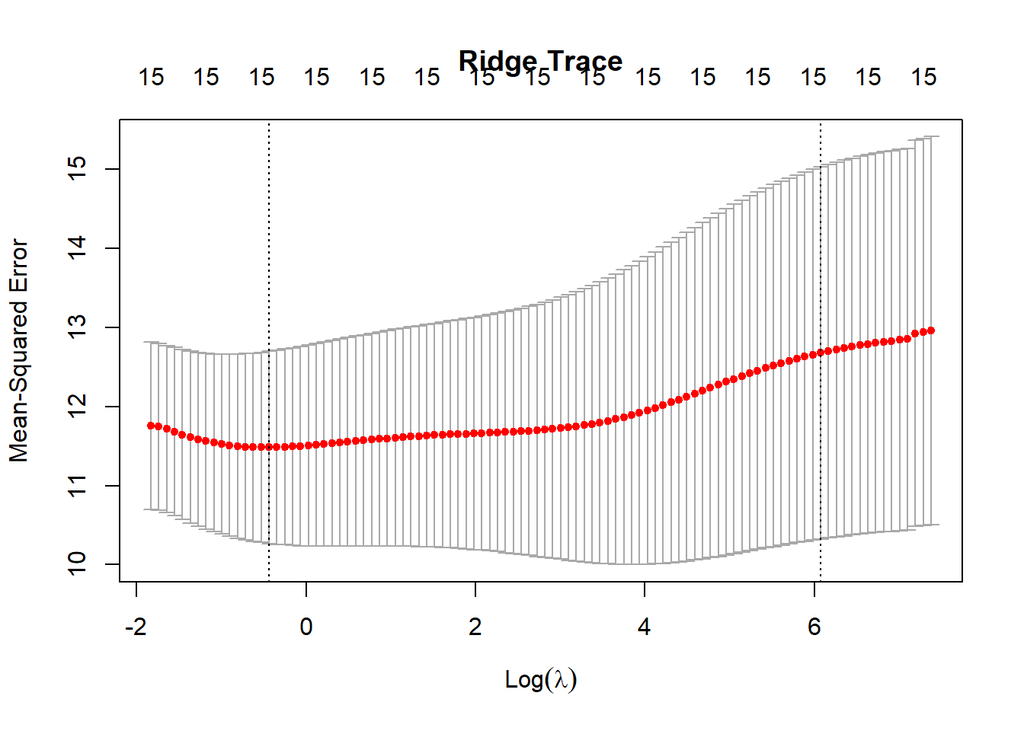

```r
x_4j = model.matrix(y ~ . -1, data = train)

set.seed(1234)
ridge_cv_4j = cv.glmnet(x_4j, train$y, alpha = 0, nfolds = 5)
plot(ridge_cv_4j, xvar = 'lambda', label = T)
title("Ridge Trace")
```

### 4(k)

```r
x_4k = model.matrix(y ~ . - 1, data = test)
mse_4k = mean((test$y - predict(ridge_cv_4j, s = ridge_cv_4j$lambda.min, x_4k))^2)
```

The MSE is 9.3658854 for the Ridge model.

### 4(l)

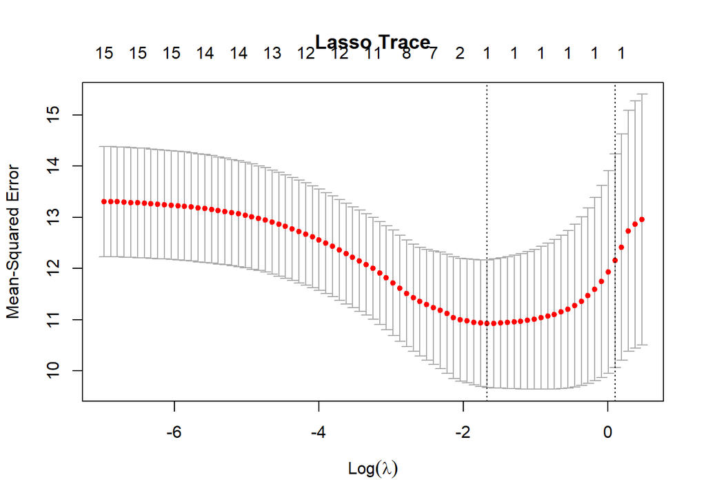

```r
x_4l = model.matrix(y ~ . -1, data = train)

set.seed(1234)
lasso_cv_4l = cv.glmnet(x_4l, train$y, alpha = 1, nfolds = 5)
plot(lasso_cv_4l, xvar = 'lambda', label = T)
title("Lasso Trace")
```

### 4(m)

```r
x_4m = model.matrix(y ~ . - 1, data = test)
mse_4m = mean((test$y - predict(lasso_cv_4l, s = lasso_cv_4l$lambda.min, x_4m))^2)
```

### 4(n)

```r
source("hw5.R")
rho = c(0.9,0.5,0.1)
sigma = c(5,3,1)

for (r in rho) {
  for (s in sigma) {
    hw5(rho = r, sigmae = s)
    cat("Rho value: ", r, " ", "Sigma value: ", s, "\n")
  }
}
```

```
## -------------------------------------------
## correlation between x:  0.9
## Error variance:  25
## OLS x1-x5: 26.24862
## OLS x1-x15: 28.4299
## backward ( 2 ): 26.96192
## forward ( 2 ): 26.96192
## ridge: 25.89624
## lasso: 25.72874
## Rho value:  0.9   Sigma value:  5
## -------------------------------------------
## correlation between x:  0.9
## Error variance:  9
## OLS x1-x5: 9.449501
## OLS x1-x15: 10.23477
## backward ( 4 ): 10.04426
## forward ( 2 ): 9.879715
## ridge: 9.365885
## lasso: 9.41732
## Rho value:  0.9   Sigma value:  3
## -------------------------------------------
## correlation between x:  0.9
## Error variance:  1
## OLS x1-x5: 1.049945
## OLS x1-x15: 1.137196
## backward ( 4 ): 1.14975
## forward ( 4 ): 1.14975
## ridge: 1.282693
## lasso: 1.269259
## Rho value:  0.9   Sigma value:  1
## -------------------------------------------
## correlation between x:  0.5
## Error variance:  25
## OLS x1-x5: 26.24862
## OLS x1-x15: 28.4299
## backward ( 4 ): 27.28365
## forward ( 2 ): 26.96062
## ridge: 27.19028
## lasso: 26.70358
## Rho value:  0.5   Sigma value:  5
```

[output cut: 35 more lines]

```
## backward ( 4 ): 10.27753
## forward ( 4 ): 10.27753
## ridge: 9.917381
## lasso: 9.858322
## Rho value:  0.1   Sigma value:  3
## -------------------------------------------
## correlation between x:  0.1
## Error variance:  1
## OLS x1-x5: 1.049945
## OLS x1-x15: 1.137196
## backward ( 6 ): 1.095551
## forward ( 6 ): 1.095551
## ridge: 1.31475
## lasso: 1.264195
## Rho value:  0.1   Sigma value:  1
```

When there is moderate to low rho/multicollinearity, OLS generally preforms better than ridge or lasso regression. Ridge or lasso regression work better when there is high multicollinearity and moderate to high noise. When using lasso or ridge we will use lasso when noise is higher. In this test they preform best when rho is 0.9 and sigma is greater than or equal to 5.